# Readme (23761067)

Talyah Greyling

### Goals

```
(1) Transform and clean data
(2) Exploratory data description of wine review data
(3) Statistical modeling of wine review data
```

### Setup defaults

```r
knitr::opts_chunk$set(echo = TRUE,
                      eval = TRUE,
                      message = FALSE,
                      warning = FALSE,
                      cache = FALSE,
                      fig.align = "center",
                      fig.pos = "H",
                      fig.width = 6,
                      fig.height = 5)
```

### Housekeeping

```r
# Clear environment
rm(list = ls())

# Load necessary packages
pacman::p_load(bonsai,
               broom,
               dbbasic,
               dplyr,
               ggplot2,
               ggwordcloud,
               glue,
               here,
               kableExtra,
               knitr,
               ldatuning,
               modeltime,
               pacman,
               pdp,
               quanteda,
               randomForest,
               readr,
               remotes,
               stopwords,
               stringr,
               targets,
               tibble,
               tidymodels,
               tidyr,
               tidytext,
               tidyverse,
               topicmodels,
               vip,
               wordcloud,
               xtable)

# Suppress scientific notation
options(scipen = 999)

# Reproducibility
set.seed(777)

# Set theme & colour palette
palette <- c("#4d8049", "#3A7370", "#FFC57B", "#FB9072", "#CE677A", "#9c0315")

# Import data
data <- readRDS("data/calitzdorp.rds")
```

## Goal (1): Transform and clean data

### Explore dataset

```r
data %>%
    sample_n(1) %>%
    t
```

```
##                                                        [,1]
## id                                                     "73542550"
## rating                                                 "3.5"
## note                                                   "Tropical flavours. Easy drinking. Perfect for summer."
## language                                               "en"
## created_at                                             "2017-07-29 16:06:00"
## aggregated                                             "TRUE"
## flavor_word_matches                                    "tropical"
## tagged_note                                            "Tropical flavours. Easy drinking. Perfect for summer."
## user_id                                                "16615351"
## user_seo_name                                          "hugo.van-vu"
## user_alias                                             "Hugo Van Vuuren"
## user_is_featured                                       "FALSE"
## user_is_premium                                        "FALSE"
## user_visibility                                        "all"
## user_language                                          "en"
## user_image_location                                    "//images.vivino.com/avatars/BRGKkzw-R9qxjoUoXCE3Tw.jpg"
## user_image_variations_large                            "//thumbs.vivino.com/avatars/BRGKkzw-R9qxjoUoXCE3Tw_300x300.jpg"
## user_image_variations_small_square                     "//thumbs.vivino.com/avatars/BRGKkzw-R9qxjoUoXCE3Tw_50x50.jpg"
## user_statistics_followers_count                        "157"
## user_statistics_followings_count                       "137"
## user_statistics_ratings_count                          "658"
## user_statistics_ratings_sum                            "2474"
## user_statistics_reviews_count                          "657"
## user_statistics_purchase_order_count                   "0"
## user_background_image_location                         "//images.vivino.com/users/backgrounds/default_1.jpg"
## user_background_image_variations_large                 "//images.vivino.com/users/backgrounds/default_1_1200x400.jpg"
## user_background_image_variations_medium                "//images.vivino.com/users/backgrounds/default_1_600x200.jpg"
## user_background_image_variations_small                 "//images.vivino.com/users/backgrounds/default_1_140x60.jpg"
## vintage_id                                             "143644225"
## vintage_seo_name                                       "de-krans-free-run-unwooded-chenin-blanc-2016"
## vintage_name                                           "De Krans Free-Run Unwooded Chenin Blanc 2016"
## vintage_organic_certification_id                       NA
## vintage_certified_biodynamic                           NA
## vintage_year                                           "2016"
## vintage_grapes                                         NA
## vintage_has_valid_ratings                              "FALSE"
## vintage_statistics_status                              "BelowThreshold"
## vintage_statistics_ratings_count                       "10"
## vintage_statistics_ratings_average                     "0"
```

[output cut: 53 more lines]

```
## vintage_wine_winery_status                             "0"
## vintage_wine_winery_review_status                      "Completed"
## vintage_wine_winery_background_image                   NA
## vintage_wine_winery_statistics_ratings_count           "5611"
## vintage_wine_winery_statistics_ratings_average         "3.8"
## vintage_wine_winery_statistics_labels_count            "28829"
## vintage_wine_winery_statistics_wines_count             "55"
## vintage_wine_statistics_status                         "Normal"
## vintage_wine_statistics_ratings_count                  "190"
## vintage_wine_statistics_ratings_average                "3.5"
## vintage_wine_statistics_labels_count                   "835"
## vintage_wine_statistics_vintages_count                 "24"
## activity_id                                            "194978815"
## activity_statistics_likes_count                        "16"
## activity_statistics_comments_count                     "2"
```

#### Table 1: Description of variables utilised for analysis

```r
# Create and populate data frame
df1 <- data.frame(
    Variable = c("id", "rating", "note", "language"),
    Description = c("Identification code of review",
                    "Rating out of 5 assigned to the wine by the reviewer",
                    "Note written about the wine by the reviewer",
                    "Language of the review"))

table1 <- print(xtable(df1),
                    type = "html",
                    include.rownames = TRUE,
                    print.results = FALSE)
table1
```

[1] “

|  | Variable | Description |
| --- | --- | --- |
| 1 | id | Identification code of review |
| 2 | rating | Rating out of 5 assigned to the wine by the reviewer |
| 3 | note | Note written about the wine by the reviewer |
| 4 | language | Language of the review |

”

### Preparing dataset for analysis:

- Started with 2298 observations of 107 variables
- Extracted the 3 variables useful for my research question
- Only English observations were kept as using APIs for translation is too costly (1667 observations remaining)
- Unnested tokens (30 800 tokens were recorded)
- I followed the standard pre-processing steps of removing punctuation, numbers, symbols, characters and taking everything to lower case
- I also used the default tidyverse stop_words dataset to remove stop words (16 869 tokens remaining) using 3 respective lexicons: snowball (from the tm package), onix (from the ONIX text retrieval system) and smart (from the SMART information retrieval system).
- All clean tokes were used in the random forrest to avoid unnecessary sampling bias.

```r
# Get review data in clean token format
review_tokens <- data %>%
    filter(str_detect(language, "en")) %>% # filter for only English entries
    select(c(review_id = "id", "rating", "note")) %>%  # extract useful columns
    unnest_tokens(input = note,
                  output = word,
                  to_lower = TRUE,
                  strip_punct = TRUE,
                  strip_numeric = TRUE) %>%
    mutate(word = gsub("_", "", word)) %>%
    mutate(word = str_extract(word, "[[:alpha:]]+")) %>%
    anti_join(stop_words, by = join_by(word)) # remove stop words
```

## Goal (2): Exploratory data description of wine review data:

- Plot rating frequency of tokens
- Plot wordcloud of popular words

### Average rating counts

```r
# Calculate the average rating for each word and its count
words_ratings_counts <- review_tokens %>%
    group_by(word) %>%
    summarise(
        ave_rating = mean(rating, na.rm = TRUE),
        word_count = n(),
        .groups = "drop"
    )
```

#### Figure1: Histogram for frequency of average ratings of review tokens

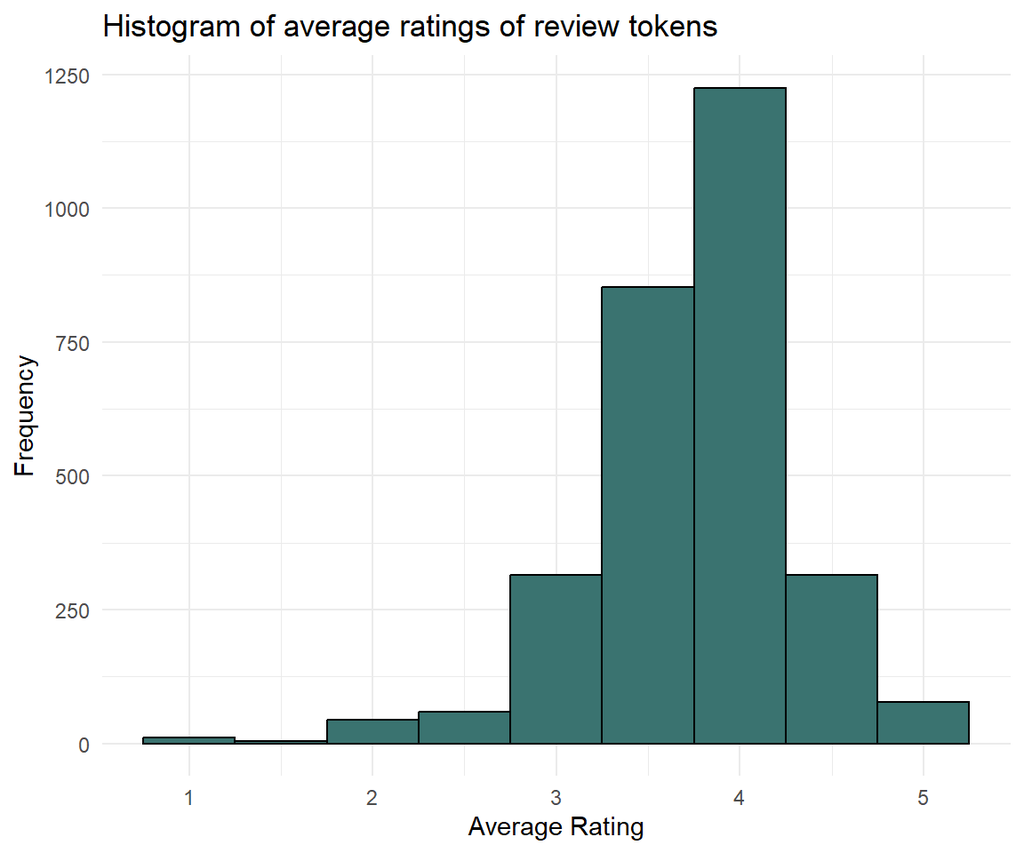

```r
# Plot histogram
fig1 <- ggplot(words_ratings_counts, aes(x = ave_rating)) +
  geom_histogram(aes(y = ..count..), binwidth =0.5, bins = 30, fill = "#3A7370", color = "black", alpha = 1) +
  theme_minimal() +
  labs(title = "Histogram of average ratings of review tokens",
       x = "Average Rating",
       y = "Frequency")
fig1
```

```r
ggsave("writeup/fig1.png", plot = fig1, width = 6, height = 5, dpi = 300)
```

### Popular tokens

```r
# Create an index that determines popular words
words_popular <- words_ratings_counts %>%
    mutate(popularity_index = 0.8 * word_count + 0.2 * ave_rating) %>%
    filter(
        word_count > 10,
        word != "",!is.na(word),!is.na(ave_rating),!is.na(word_count),!is.na(popularity_index)
    ) %>%
    filter(!word %in% stop_words) %>%
    arrange(desc(popularity_index)) %>%
    select(c(word, popularity_index))
```

#### Figure 2: Word cloud of top 50 popular words in reviews based on index

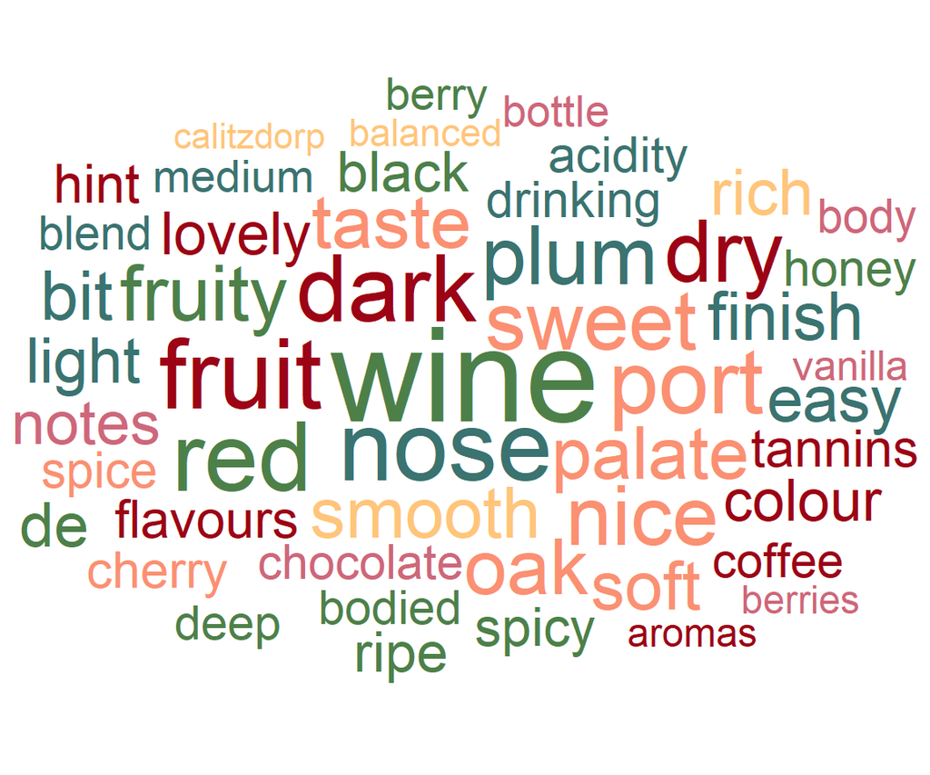

```r
# Get top 50 words
top50 <- words_popular %>%
  slice_max(order_by = popularity_index, n = 50)

# Set palette
top50$assigned_color <- sample(palette, nrow(top50), replace = TRUE)

# Create Word Cloud
fig2 <- ggplot(top50, aes(label = word, size = popularity_index, color = assigned_color)) +
  geom_text_wordcloud_area() +
  scale_size_area(max_size = 40) +
  scale_color_identity() +
  theme_minimal()
fig2
```

```r
ggsave("writeup/fig2.png", plot = fig2, width = 6, height = 5, dpi = 300)
```

## Goal (3): Statistical modeling of wine review data

- Use 2 step modelling process
- Step 1: Use RandomForest as a variable selection method (words as columns & ratings as rows) to determine the top 20 words
  - Plot training & testing data to confirm similar ratings distributions
  - Plot RF performance with different mtry values
  - Visualise top 20 with a variable importance plot
  - Visualise top 50 in a wordcloud
- Step 2: run an OLS regression of the best words to get coefficients for their probability of determining good ratings

### Step 1: Random Forest variable selection

```r
# Convert data to DTM format:
dtm <- review_tokens %>%
    group_by(review_id, word) %>%
    summarise(count = n(), .groups = "drop") %>%
    pivot_wider(names_from = word,
                values_from = count,
                values_fill = list(count = 0))

# Add back rating & drop review_id
ratings <- review_tokens %>%
    select(review_id, rating) %>%
    distinct()
dtm <- left_join(ratings, dtm, by = "review_id") %>%
    select(-review_id)

# Define training and testing sets for prediction
split_ratings <- initial_split(dtm, prop = 0.7)
training_ratings <- training(split_ratings)
testing_ratings <- testing(split_ratings)
```

#### Figure 3: Distribution of training & testing data

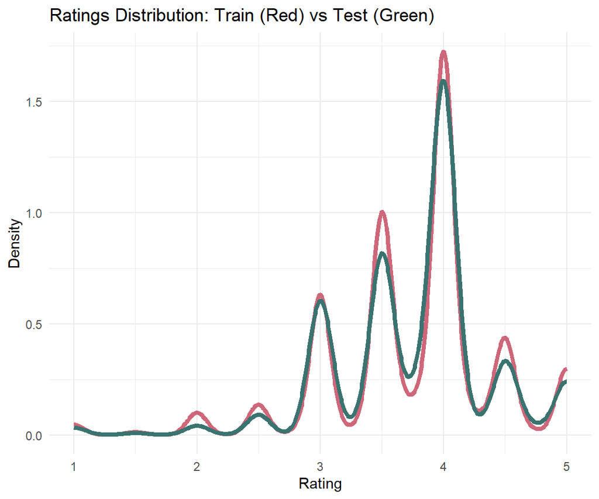

```r
# Confirm that training & testing data have similar ratings distributions
fig3 <- ggplot() +
        geom_density(data = training_ratings, aes(rating.x), linewidth = 1.5, alpha = 0.5, color = "#CE677A") +
        geom_density(data = testing_ratings, aes(rating.x), linewidth = 1.5, alpha = 0.5, color = "#3A7370") +
        scale_x_continuous(labels = scales::comma) +
        theme_minimal() +
        labs(title = "Ratings Distribution: Train (Red) vs Test (Green)", x = "Rating", y = "Density")
fig3
```

```r
ggsave("writeup/fig3.png", plot = fig3, width = 6, height = 5, dpi = 300)
```

```r
# RandomForest recipe
wine_rec <- recipe(rating.x ~ ., data = training_ratings) %>%
  step_dummy(all_nominal_predictors()) %>%
  step_zv(all_numeric_predictors()) %>%
  step_normalize(all_numeric_predictors())

# RandomForest specification model
model_spec <- rand_forest(
  mtry = tune(),
  min_n = 10,
  trees = 100
  ) %>%
  set_engine("ranger", num.threads = 10,
             importance = "permutation") %>%
  set_mode("regression")

# Inspect the low level call
model_spec %>%
    translate()
```

```
## Random Forest Model Specification (regression)
##
## Main Arguments:
##   mtry = tune()
##   trees = 100
##   min_n = 10
##
## Engine-Specific Arguments:
##   num.threads = 10
##   importance = permutation
##
## Computational engine: ranger
##
## Model fit template:
## ranger::ranger(x = missing_arg(), y = missing_arg(), weights = missing_arg(),
##     mtry = min_cols(~tune(), x), num.trees = 100, min.node.size = min_rows(~10,
##         x), num.threads = 10, importance = "permutation", verbose = FALSE,
##     seed = sample.int(10^5, 1))
```

```r
# Building the workflow
(model_workflow <- workflow() %>%
   add_recipe(wine_rec) %>%
   add_model(model_spec))
```

```
## ══ Workflow ════════════════════════════════════════════════════════════════════
## Preprocessor: Recipe
## Model: rand_forest()
##
## ── Preprocessor ────────────────────────────────────────────────────────────────
## 3 Recipe Steps
##
## • step_dummy()
## • step_zv()
## • step_normalize()
##
## ── Model ───────────────────────────────────────────────────────────────────────
## Random Forest Model Specification (regression)
##
## Main Arguments:
##   mtry = tune()
##   trees = 100
##   min_n = 10
##
## Engine-Specific Arguments:
##   num.threads = 10
##   importance = permutation
##
## Computational engine: ranger
```

```r
# Cross validation
(cv_folds <- vfold_cv(training_ratings, v = 5, repeats = 1))
```

```
## #  5-fold cross-validation
## # A tibble: 5 × 2
##   splits            id
##   <list>            <chr>
## 1 <split [929/233]> Fold1
## 2 <split [929/233]> Fold2
## 3 <split [930/232]> Fold3
## 4 <split [930/232]> Fold4
## 5 <split [930/232]> Fold5
```

```r
# Set regular grid
grid_vals <- grid_regular(mtry(range = c(10, 18)), levels = 5)

model_res <- model_workflow %>%
  tune_grid(
    resamples = cv_folds,
    grid = grid_vals,
    control = control_grid(save_pred = TRUE),
    metrics = metric_set(rmse)
  )
```

#### Figure 4:

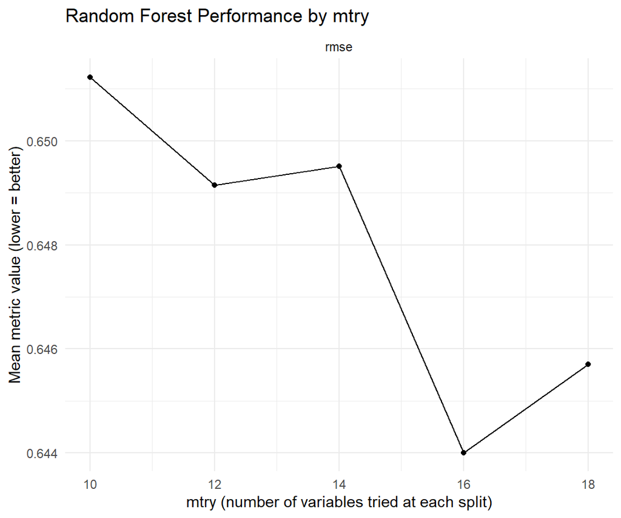

```r
# Evaluate how RF performs with different mtry values
fig4 <- model_res %>%
  collect_metrics() %>%
  ggplot(aes(x = mtry, y = mean)) +
  geom_point() +
  geom_line() +
  facet_wrap(~.metric, scales = "free_y") +
  labs(
    title = "Random Forest Performance by mtry",
    x = "mtry (number of variables tried at each split)",
    y = "Mean metric value (lower = better)",
    color = "mtry"
  ) +
  theme_minimal()
fig4
```

```r
ggsave("writeup/fig4.png", plot = fig4, width = 6, height = 5, dpi = 300)
```

```r
# final fit and evaluation
best_params <- model_res %>%
  show_best(metric = "rmse") %>%
  slice(1)

# Plug optimal hyperparameters into workflow & fit on all training data
(final_model <- finalize_workflow(model_workflow, best_params))
```

```
## ══ Workflow ════════════════════════════════════════════════════════════════════
## Preprocessor: Recipe
## Model: rand_forest()
##
## ── Preprocessor ────────────────────────────────────────────────────────────────
## 3 Recipe Steps
##
## • step_dummy()
## • step_zv()
## • step_normalize()
##
## ── Model ───────────────────────────────────────────────────────────────────────
## Random Forest Model Specification (regression)
##
## Main Arguments:
##   mtry = 16
##   trees = 100
##   min_n = 10
##
## Engine-Specific Arguments:
##   num.threads = 10
##   importance = permutation
##
## Computational engine: ranger
```

```r
final_fit <- final_model %>%
  fit(data = training_ratings)

# Inspect trained model
final_fit %>%
  extract_fit_parsnip()
```

```
## parsnip model object
##
## Ranger result
##
## Call:
##  ranger::ranger(x = maybe_data_frame(x), y = y, mtry = min_cols(~16L,      x), num.trees = ~100, min.node.size = min_rows(~10, x), num.threads = ~10,      importance = ~"permutation", verbose = FALSE, seed = sample.int(10^5,          1))
##
## Type:                             Regression
## Number of trees:                  100
## Sample size:                      1162
## Number of independent variables:  2417
## Mtry:                             16
## Target node size:                 10
## Variable importance mode:         permutation
## Splitrule:                        variance
## OOB prediction error (MSE):       0.4278301
## R squared (OOB):                  0.0813589
```

```r
# Asses how model performs on unseen data
metricsdata <- predict(final_fit, testing_ratings) %>%
  bind_cols(testing_ratings) %>%
  metrics(truth = rating.x, estimate = .pred)
```

#### Table 2: Model Performance Metrics

```r
xtab_metrics <- xtable(metricsdata,
                       caption = "Model Performance Metrics",
                       digits = c(0, 0, 4, 4))

table2 <- print(xtable(xtab_metrics),
                    type = "html",
                    include.rownames = FALSE,
                    caption.placement = "top",
                    print.results = FALSE)
table2
```

[1] “

| .metric | .estimator | .estimate |
| --- | --- | --- |
| rmse | standard | 0.60 |
| rsq | standard | 0.14 |
| mae | standard | 0.44 |

”

#### Figure 5: Variable Importance Plot of top 20 words in reviews identified by Random Forest model

```r
# Which features had the most influence on predictions
fitted_model <- final_fit %>%
    extract_fit_parsnip()
varimp <- vi(fitted_model)
varimp
```

```
## # A tibble: 2,417 × 2
##    Variable  Importance
##    <chr>          <dbl>
##  1 excellent    0.00641
##  2 delicious    0.00511
##  3 port         0.00358
##  4 amazing      0.00281
##  5 chalky       0.00281
##  6 fantastic    0.00264
##  7 elegant      0.00253
##  8 bland        0.00252
##  9 decent       0.00228
## 10 thin         0.00215
## # ℹ 2,407 more rows
```

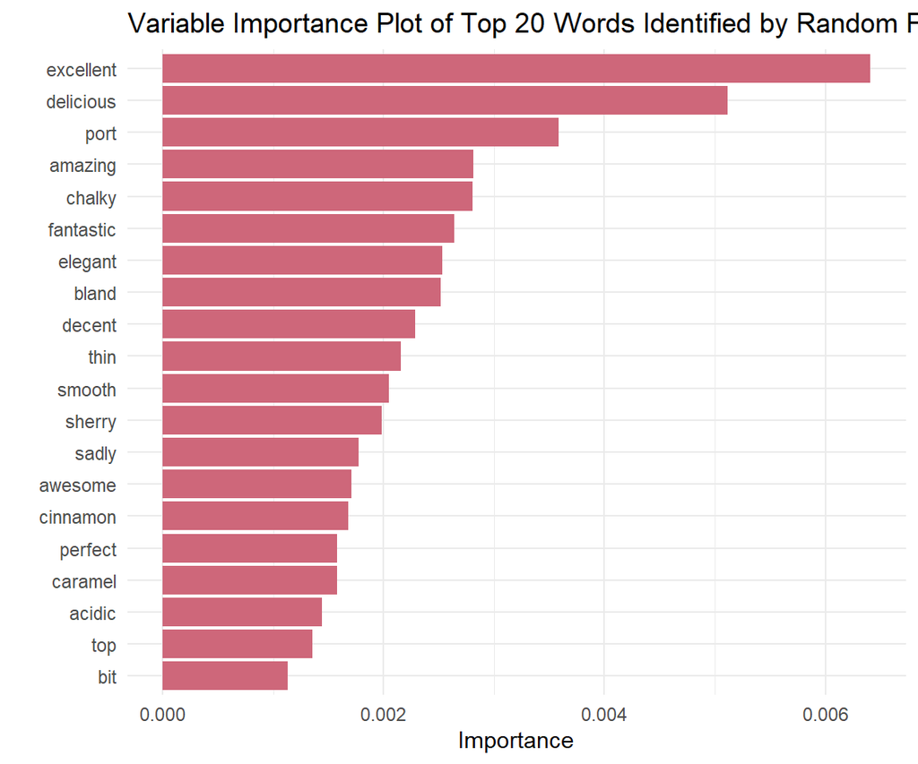

```r
# Draw VIP
fig5 <- vip(fitted_model, num_features = 20, geom = "col",
    aesthetics = list(fill = "#CE677A")) +
    labs(
    title = "Variable Importance Plot of Top 20 Words Identified by Random Forest") +
  theme_minimal()
fig5
```

```r
ggsave("writeup/fig5.png", plot = fig5, width = 6, height = 5, dpi = 300)
```

#### Figure 6: Word cloud of top 50 words in reviews identified by Random Forest model

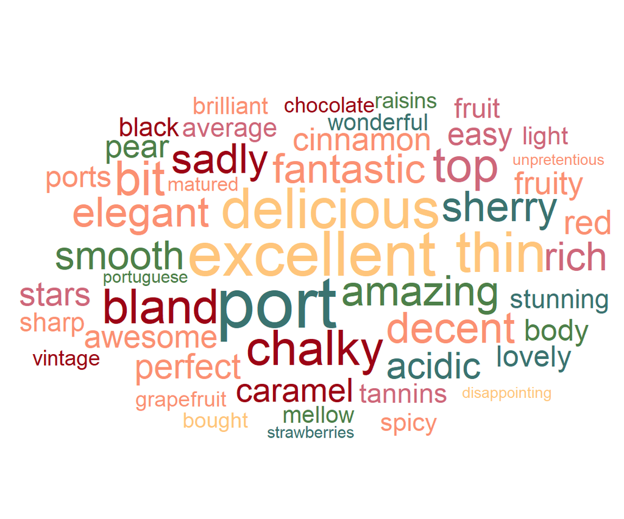

```r
# Convert data for wordcloud
df_wordcloud <- vi(fitted_model) %>%
  arrange(desc(Importance)) %>%
  slice(1:50) %>%
    select(word = Variable, freq = Importance)

# Set palette
df_wordcloud$assigned_color <- sample(palette, nrow(df_wordcloud), replace = TRUE)

# Create Word Cloud
fig6 <- ggplot(df_wordcloud, aes(label = word, size = freq, color = assigned_color)) +
  geom_text_wordcloud_area() +
  scale_size_area(max_size = 40) +
  scale_color_identity() +
  theme_minimal()
fig6
```

```r
ggsave("writeup/fig6.png", plot = fig6, width = 6, height = 5, dpi = 300)
```

### Step 2: OLS regression

```r
# Filter dtm by top 20 words determined by RF
top_20 <- vip(fitted_model, num_features = 20)$data$Variable
df_ols <- dtm %>%
  select(rating.x, all_of(top_20))

ols_model <- lm(rating.x ~ ., data = df_ols)
summary(ols_model)
```

```
##
## Call:
## lm(formula = rating.x ~ ., data = df_ols)
##
## Residuals:
##      Min       1Q   Median       3Q      Max
## -3.03477 -0.26826  0.07016  0.33862  1.58584
##
## Coefficients:
##             Estimate Std. Error t value             Pr(>|t|)
## (Intercept)  3.66138    0.01842 198.812 < 0.0000000000000002 ***
## excellent    0.53196    0.09384   5.669          0.000000017 ***
## delicious    0.38120    0.08696   4.384          0.000012414 ***
## port         0.11911    0.04449   2.677             0.007494 **
## amazing      0.41670    0.11234   3.709             0.000215 ***
## chalky      -1.10079    0.31261  -3.521             0.000441 ***
## fantastic    0.49815    0.13405   3.716             0.000209 ***
## elegant      0.27754    0.11972   2.318             0.020554 *
## bland       -1.62664    0.36067  -4.510          0.000006941 ***
## decent      -0.46843    0.16713  -2.803             0.005127 **
## thin        -0.76824    0.23947  -3.208             0.001362 **
## smooth       0.22568    0.04727   4.774          0.000001967 ***
## sherry      -0.63234    0.23917  -2.644             0.008273 **
## sadly       -0.81362    0.21063  -3.863             0.000116 ***
## awesome      0.59393    0.15673   3.789             0.000156 ***
## cinnamon     0.27453    0.11234   2.444             0.014641 *
## perfect      0.37339    0.08506   4.390          0.000012071 ***
## caramel      0.19515    0.08784   2.222             0.026438 *
## acidic      -0.24722    0.13058  -1.893             0.058508 .
## top          0.53055    0.18306   2.898             0.003803 **
## bit         -0.10421    0.07234  -1.441             0.149911
## ---
## Signif. codes:  0 '***' 0.001 '**' 0.01 '*' 0.05 '.' 0.1 ' ' 1
##
## Residual standard error: 0.6227 on 1640 degrees of freedom
## Multiple R-squared:  0.1447, Adjusted R-squared:  0.1343
## F-statistic: 13.87 on 20 and 1640 DF,  p-value: < 0.00000000000000022
```

#### Table 3: OLS Regression Results (Top 20 Words)

```r
ols_table <- xtable(ols_model,
                    caption = "OLS Regression Results (Top 20 Words)")

table3 <- print(ols_table,
      type = "html",
      include.rownames = TRUE,
      caption.placement = "top",
      print.results = FALSE)
table3
```

[1] “

OLS Regression Results (Top 20 Words)

|  | Estimate | Std. Error | t value | Pr(>\|t\|) |
| --- | --- | --- | --- | --- |
| (Intercept) | 3.6614 | 0.0184 | 198.81 | 0.0000 |
| excellent | 0.5320 | 0.0938 | 5.67 | 0.0000 |
| delicious | 0.3812 | 0.0870 | 4.38 | 0.0000 |
| port | 0.1191 | 0.0445 | 2.68 | 0.0075 |
| amazing | 0.4167 | 0.1123 | 3.71 | 0.0002 |
| chalky | -1.1008 | 0.3126 | -3.52 | 0.0004 |
| fantastic | 0.4982 | 0.1340 | 3.72 | 0.0002 |
| elegant | 0.2775 | 0.1197 | 2.32 | 0.0206 |
| bland | -1.6266 | 0.3607 | -4.51 | 0.0000 |
| decent | -0.4684 | 0.1671 | -2.80 | 0.0051 |
| thin | -0.7682 | 0.2395 | -3.21 | 0.0014 |
| smooth | 0.2257 | 0.0473 | 4.77 | 0.0000 |
| sherry | -0.6323 | 0.2392 | -2.64 | 0.0083 |
| sadly | -0.8136 | 0.2106 | -3.86 | 0.0001 |
| awesome | 0.5939 | 0.1567 | 3.79 | 0.0002 |
| cinnamon | 0.2745 | 0.1123 | 2.44 | 0.0146 |
| perfect | 0.3734 | 0.0851 | 4.39 | 0.0000 |
| caramel | 0.1951 | 0.0878 | 2.22 | 0.0264 |
| acidic | -0.2472 | 0.1306 | -1.89 | 0.0585 |
| top | 0.5305 | 0.1831 | 2.90 | 0.0038 |
| bit | -0.1042 | 0.0723 | -1.44 | 0.1499 |

”

### Visualising OLS regression

```r
# Tidy results
ols_results <- broom::tidy(ols_model) %>%
  arrange(desc(estimate))

# Filter out intercept and format
final_results <- ols_results %>%
  filter(term != "(Intercept)") %>%
  select(term, estimate, p.value) %>%
  mutate(
    effect = ifelse(estimate > 0, "Positive", "Negative"),
    term = fct_reorder(term, estimate)
  )
final_results
```

```
## # A tibble: 20 × 4
##    term      estimate      p.value effect
##    <fct>        <dbl>        <dbl> <chr>
##  1 awesome      0.594 0.000156     Positive
##  2 excellent    0.532 0.0000000170 Positive
##  3 top          0.531 0.00380      Positive
##  4 fantastic    0.498 0.000209     Positive
##  5 amazing      0.417 0.000215     Positive
##  6 delicious    0.381 0.0000124    Positive
##  7 perfect      0.373 0.0000121    Positive
##  8 elegant      0.278 0.0206       Positive
##  9 cinnamon     0.275 0.0146       Positive
## 10 smooth       0.226 0.00000197   Positive
## 11 caramel      0.195 0.0264       Positive
## 12 port         0.119 0.00749      Positive
## 13 bit         -0.104 0.150        Negative
## 14 acidic      -0.247 0.0585       Negative
## 15 decent      -0.468 0.00513      Negative
## 16 sherry      -0.632 0.00827      Negative
## 17 thin        -0.768 0.00136      Negative
## 18 sadly       -0.814 0.000116     Negative
## 19 chalky      -1.10  0.000441     Negative
## 20 bland       -1.63  0.00000694   Negative
```

#### Figure 7: Plot of coefficients on OLS regression of top 20 words in reviews identified by RandomForest model

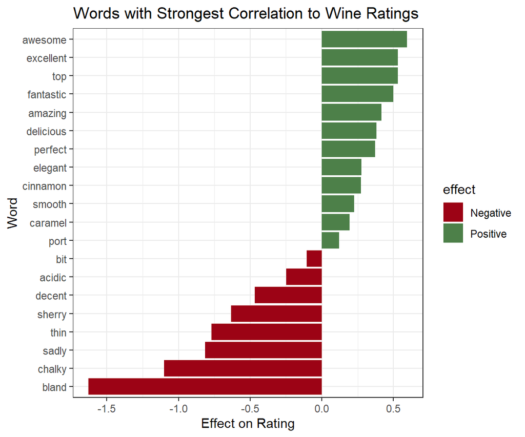

```r
fig7 <-  ggplot(final_results, aes(x = estimate, y = term, fill = effect)) +
  geom_col() +
  scale_fill_manual(values = c("#9c0315", "#4d8049")) +
  labs(
    title = "Words with Strongest Correlation to Wine Ratings",
    x = "Effect on Rating",
    y = "Word"
  ) +
  theme_bw()
fig7
```

```r
ggsave("writeup/fig7.png", plot = fig7, width = 6, height = 5, dpi = 300)
```